# Estimating a Flood Inundation Probability Map

CPLN 675 Assignment3

Riddhi Batra & Charlie Townsley

2023-03-28

# Introduction

The goal of this project is to use existing flood inundation and environmental data from the city of Calgary in Alberta, Canada, to build a predictive model that estimates flooding in a comparison city with similar characteristics (Denver, Colorado).

In the United States, floods are responsible for roughly $8 billion in damage every year.

Predictive flood modeling is important for helping cities plan, prepare for, and respond to flood events.

This type of process is different from basic site suitability studies or detailed hydraulic modeling because it quickly maps relative risk. Such “general linear models” can help city planning departments quickly and cheaply prioritize disaster preparation and response.

```r
mapTheme <- theme(plot.title =element_text(size=12),
                  plot.subtitle = element_text(size=8),
                  plot.caption = element_text(size = 6),
                  axis.line=element_blank(),
                  axis.text.x=element_blank(),
                  axis.text.y=element_blank(),
                  axis.ticks=element_blank(),
                  axis.title.x=element_blank(),
                  axis.title.y=element_blank(),
                  panel.background=element_blank(),
                  panel.border=element_blank(),
                  panel.grid.major=element_line(colour = 'transparent'),
                  panel.grid.minor=element_blank(),
                  legend.direction = "vertical",
                  legend.position = "right",
                  plot.margin = margin(1, 1, 1, 1, 'cm'),
                  legend.key.height = unit(1, "cm"), legend.key.width = unit(0.2, "cm"))

plotTheme <- theme(
  plot.title =element_text(size=12),
  plot.subtitle = element_text(size=8),
  plot.caption = element_text(size = 6),
  axis.text.x = element_text(size = 10, angle = 45, hjust = 1),
  axis.text.y = element_text(size = 10),
  axis.title.y = element_text(size = 10),
  # Set the entire chart region to blank
  panel.background=element_blank(),
  plot.background=element_blank(),
  #panel.border=element_rect(colour="#F0F0F0"),
  # Format the grid
  panel.grid.major=element_line(colour="#D0D0D0",size=.75),
  axis.ticks=element_blank())

#color nerds

blues <- c("#CEEBF0", "#A2D3D8", "#73B8BF", "#51A6AE", "#468D94", "#34696E")

greens <- c("#D8E5CE", "#C1D4B5", "#A9BF99", "#92AF7E", "#81996F", "#668053")

yellows <- c("#F9E2B2", "#EDC876", "#EDBA46", "#EDB025", "#AC832D", "#6E5321")

greys <- c("#ECEBF1", "#D3D3D9", "#B0B0B3", "#9C9C9E", "#7F7F80", "#656666")

neutrals <- c("#FDF4E9", "#FFEFDE", "#F6D7B2", "#D6B28B", "#A58565")
```

```r
denver_boundary <-read_sf("Denver/Processed/LUEM_Asgn3_Denver/NewData/denver_bound/denver_bound.shp")

calgary_boundary <- read_sf("Calgary/Raw/CALGIS_CITYBOUND_LIMIT/CALGIS_CITYBOUND_LIMIT.shp")
```

# Fishnets

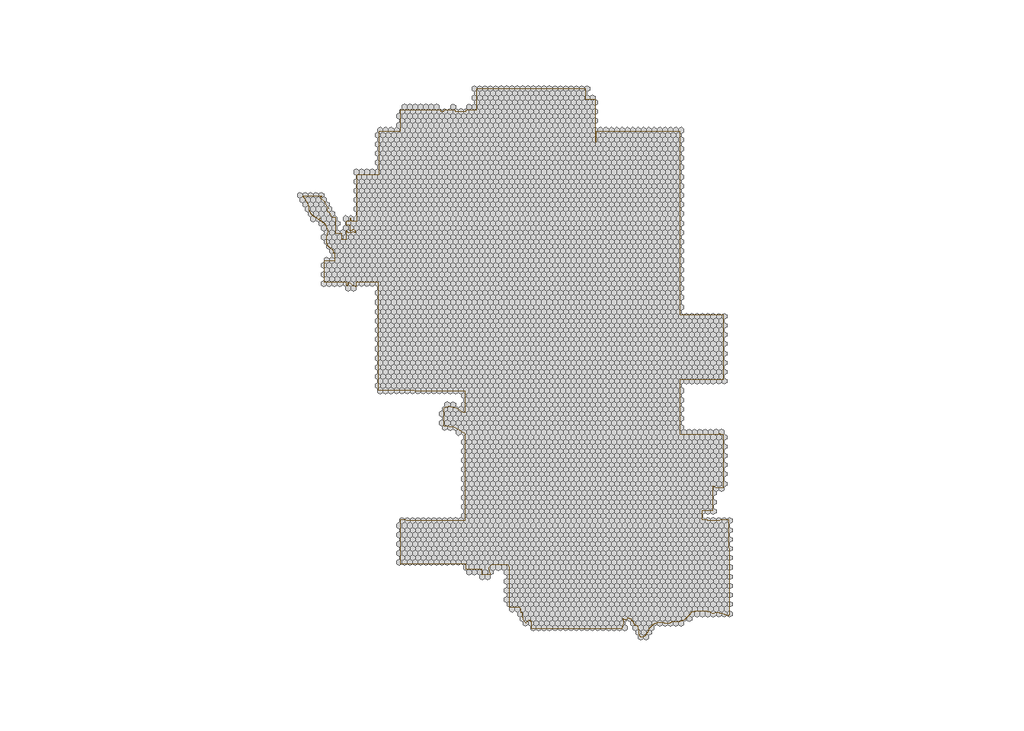

```r
calgary_fishnet <- st_make_grid(calgary_boundary,
                        cellsize = 402.336,
                        square = FALSE) %>%
  .[calgary_boundary] %>%
  st_sf() %>%
  mutate(uniqueID = rownames(.))

ggplot()+
  geom_sf(data = calgary_fishnet,
          fill = "lightgrey")+
  geom_sf(data = calgary_boundary,
          color = "#6E5321", fill = "transparent") +
  mapTheme
```

```r
#st_write(calgary_fishnet, "Calgary/Processed/calgary_fishnet/calgary_fishnet.shp", geometry = TRUE)
```

Create a fishnet for Denver to do processing in ArcGIS.

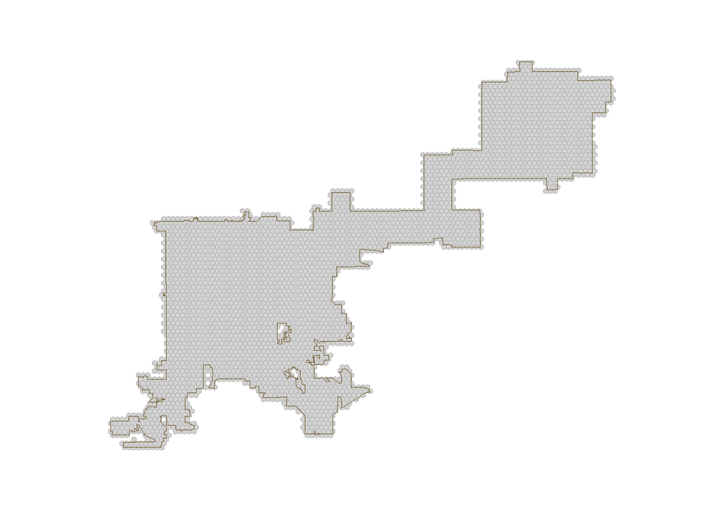

```r
denver_fishnet <- st_make_grid(denver_boundary,
                        cellsize = 1320,
                        square = FALSE) %>%
  .[denver_boundary] %>%
  st_sf() %>%
  mutate(uniqueID = rownames(.))

ggplot()+
  geom_sf(data = denver_fishnet,
          color="darkgrey", fill = "lightgrey") +
  geom_sf(data = denver_boundary,
          color = "#6E5321", fill = "transparent") +
  mapTheme
```

```r
#st_write(denver_fishnet, "Denver/Processed/R exports/denver_fishnet/denver_fishnet.shp", geometry = TRUE)
```

## Feature Engineering: Arc to R

After creating fishnets for Calgary and Denver in R, we exported them as shapefiles for processing in ArcGIS. where we created tables of zonal statistics from relevant raster data.

```r
#load in cleaned fishnet with partial cells removed
calgary_fishnet <-  read_sf("Calgary/Processed/calgary_fishnet_nozeros/calgary_fishnet_nozeros.shp")

#load in engineered features for calgary and process
calg_inund <- read_csv("Calgary/Processed/zonalstats_tables/calg_inundation_sum.csv") %>%
  rename(inund_sum = SUM) %>%
  dplyr::select(uniqueID, inund_sum) %>%
  mutate(inund_sum = ifelse(inund_sum >= 16, 1, 0)) #turn inundation sum values into binary (threshold = 16)

calg_pervious <- read.csv("Calgary/Processed/zonalstats_tables/calg_pervious_mean.csv") %>%
  dplyr::select(uniqueID, MEAN) %>%
  rename(pervious_mean = MEAN)

calg_elevation <- read.csv("Calgary/Processed/zonalstats_tables/calg_elevation_mean.csv") %>%
    dplyr::select(uniqueID, MEAN) %>%
  rename(elevation_mean = MEAN)

calg_flowac <- read.csv("Calgary/Processed/zonalstats_tables/calg_flowac_mean.csv") %>%
    dplyr::select(uniqueID, MEAN) %>%
  rename(flowac_mean = MEAN)

calg_streamdist <- read.csv("Calgary/Processed/zonalstats_tables/calg_dist2stream_min.csv") %>%
    dplyr::select(uniqueID, MIN) %>%
  rename(streamdist_min = MIN)

calg_dat <- calgary_fishnet %>%
  mutate(uniqueID = as.integer(uniqueID)) %>%
  left_join(calg_inund, by = "uniqueID") %>%
  left_join(calg_pervious, by = "uniqueID") %>%
  left_join(calg_elevation, by = "uniqueID") %>%
  left_join(calg_flowac, by = "uniqueID") %>%
  left_join(calg_streamdist, by = "uniqueID") %>%
  mutate(flowac_mean_log = log(flowac_mean),
         streamdist_min_log = log(streamdist_min)) %>%
  na.omit() %>%
    dplyr::mutate(streamdist_min_log = if_else(streamdist_min_log <0, 0, streamdist_min_log),
         flowac_mean_log = if_else(flowac_mean_log <0, 0, flowac_mean_log)) %>%
  na.omit()
```

```r
denv_pervious <- read.csv ("Denver/Processed/zonalstats_tables/denv_pervious_mean.csv") %>%
  dplyr::select(uniqueID, MEAN) %>%
  rename(pervious_mean = MEAN)

denv_elevation <- read.csv("Denver/Processed/zonalstats_tables/denver_elevation_mean.csv") %>%
  dplyr::select(uniqueID, MEAN) %>%
  rename(elevation_mean = MEAN)


denv_flowac <- read.csv("Denver/Processed/zonalstats_tables/denv_flowac_mean.csv") %>%
    dplyr::select(uniqueID, MEAN) %>%
  rename(flowac_mean = MEAN)


denv_streamdist <- read.csv("Denver/Processed/zonalstats_tables/denv_dist2stream_min.csv") %>%
    dplyr::select(uniqueID, MIN) %>%
  rename(streamdist_min = MIN)


denver_dat <- denver_fishnet %>%
  mutate(uniqueID = as.integer(uniqueID)) %>%
  left_join(denv_pervious, by = 'uniqueID') %>%
  left_join(denv_elevation, by = 'uniqueID') %>%
  left_join(denv_flowac, by = 'uniqueID') %>%
  left_join(denv_streamdist, by = 'uniqueID') %>%
  mutate(flowac_mean = flowac_mean*0.3048,
         streamdist_min = streamdist_min*0.3048) %>%
    mutate(flowac_mean_log = log(flowac_mean),
         streamdist_min_log = log(streamdist_min)) %>%
  na.omit() %>%
    dplyr::mutate(streamdist_min_log = if_else(streamdist_min_log <0, 0, streamdist_min_log),
         flowac_mean_log = if_else(flowac_mean_log <0, 0, flowac_mean_log))
```

### Calgary

Below are the features we created for Calgary:

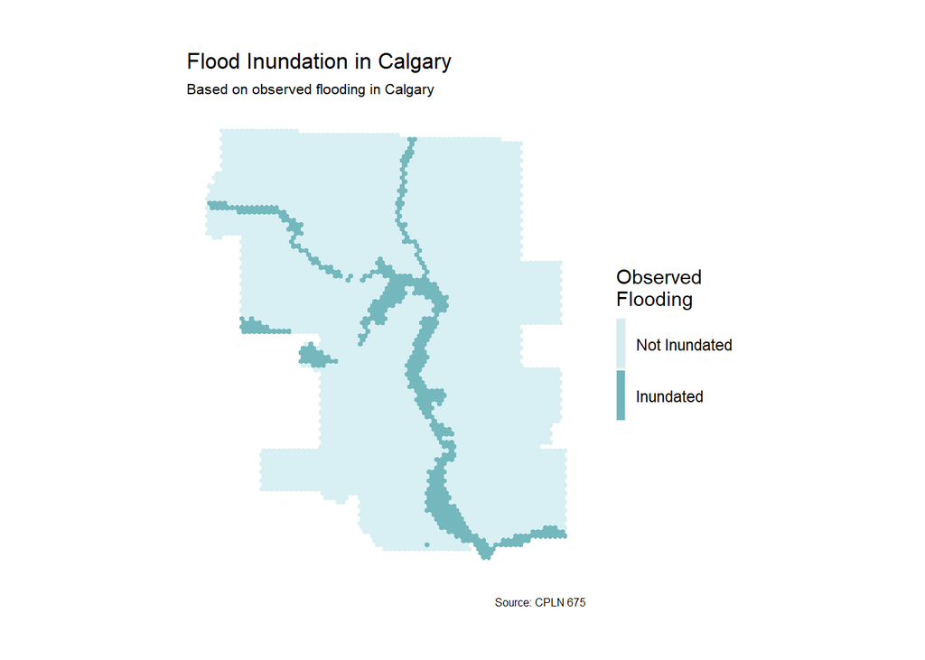

```r
calg_dat <- calg_dat %>%
  st_transform(crs = 3776)

ggplot() +
  geom_sf(data=calg_dat, aes(fill=as.factor(inund_sum)), alpha = 0.8, color = NA) +
  scale_fill_manual(values = c("#CEEBF0", "#51A6AE"),
                    labels = c("Not Inundated", "Inundated"),
                    name = "Observed\nFlooding") +
  labs(title="Flood Inundation in Calgary",
       subtitle="Based on observed flooding in Calgary",
        caption = "Source: CPLN 675") +
  mapTheme
```

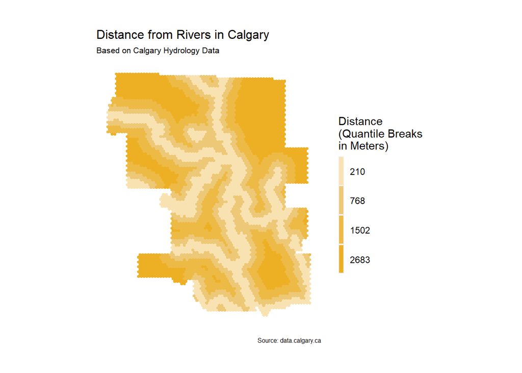

```r
ggplot() +
  geom_sf(data=calg_dat, aes(fill=factor(ntile(streamdist_min, 4))),
            colour=NA) +
  scale_fill_manual(values = yellows,
                    labels= as.character(round(quantile(calg_dat$streamdist_min,
                                                 c(0.2,.4,.6,.8),
                                                 na.rm=T))),
                    name = "Distance\n(Quantile Breaks\nin Meters)") +
  labs(title="Distance from Rivers in Calgary",
      subtitle="Based on Calgary Hydrology Data",
      caption = "Source: data.calgary.ca") +
  mapTheme
```

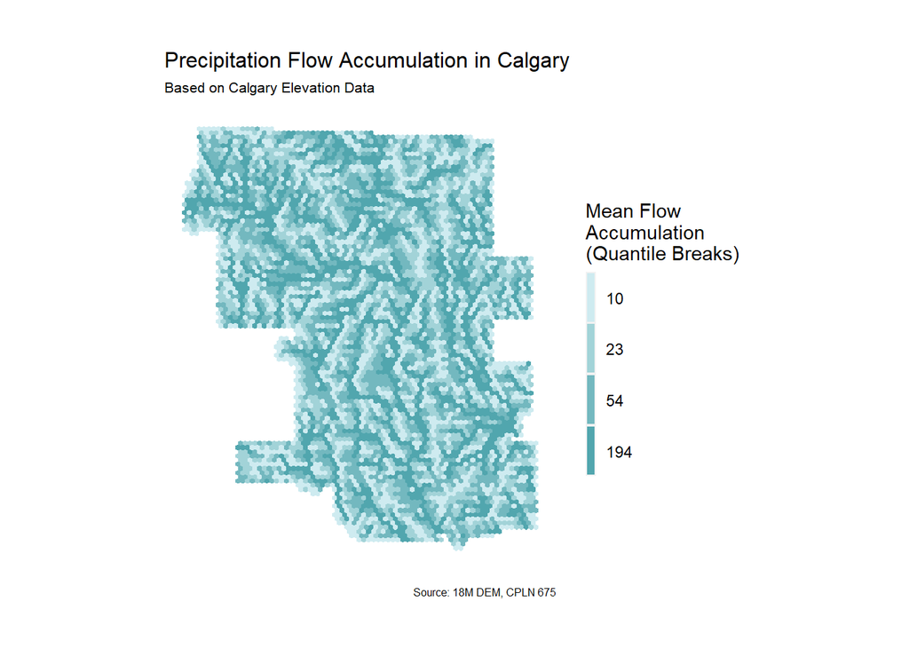

```r
ggplot() +
  geom_sf(data=calg_dat, aes(fill=factor(ntile(flowac_mean,4))),
            colour=NA) +
  scale_fill_manual(values = blues,
                    labels= as.character(round(quantile(calg_dat$flowac_mean,
                                                 c(0.2,.4,.6,.8),
                                                 na.rm=T))),
                    name = "Mean Flow\nAccumulation\n(Quantile Breaks)") +
  labs(title="Precipitation Flow Accumulation in Calgary",
       subtitle="Based on Calgary Elevation Data",
        caption = "Source: 18M DEM, CPLN 675") +
  mapTheme
```

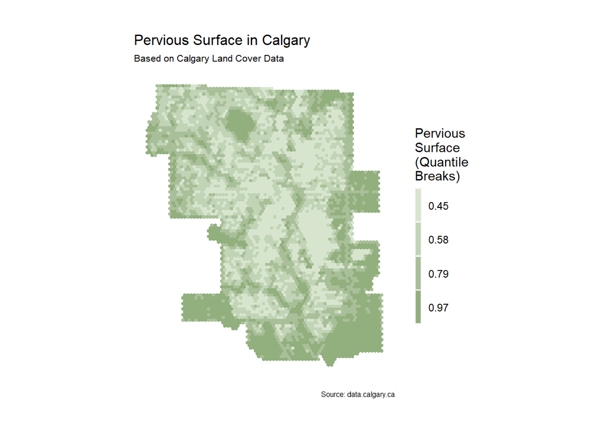

```r
ggplot() +
  geom_sf(data=calg_dat, aes(fill=factor(ntile(pervious_mean,4))),
            colour=NA) +
  scale_fill_manual(values = greens,
                    labels= as.character(round(quantile(calg_dat$pervious_mean,
                                                 c(0.2,.4,.6,.8),
                                                 na.rm=T), 2)),
                    name = "Pervious\nSurface\n(Quantile\nBreaks)") +
  labs(title="Pervious Surface in Calgary",
       subtitle="Based on Calgary Land Cover Data",
        caption = "Source: data.calgary.ca") +
  mapTheme
```

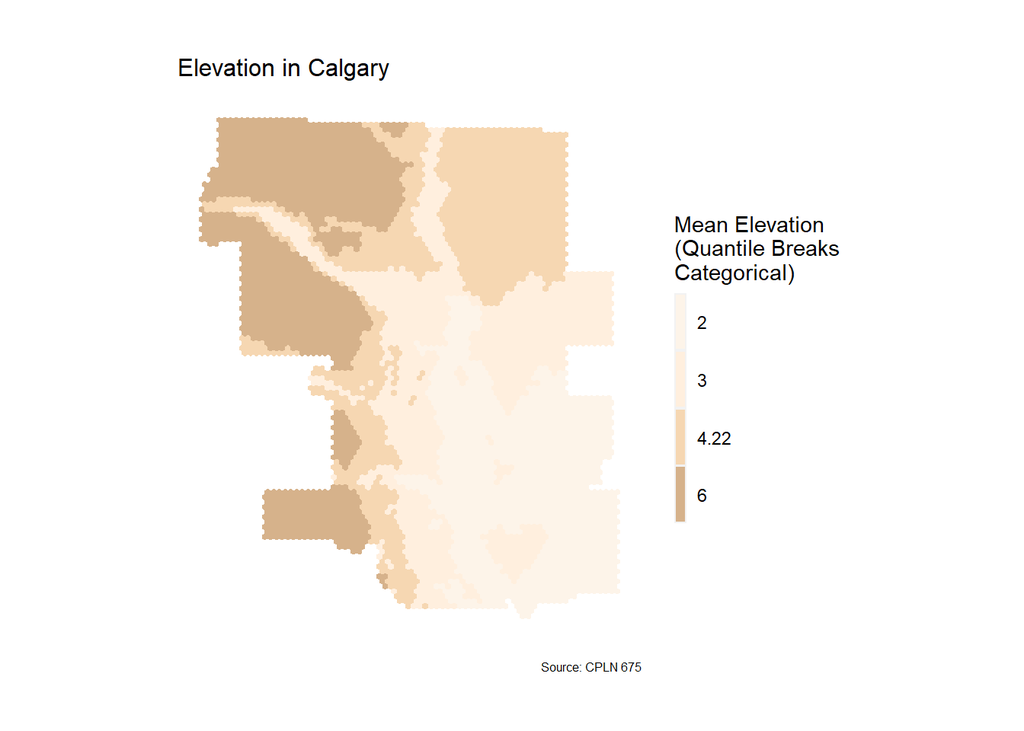

```r
ggplot() +
  geom_sf(data=calg_dat, aes(fill=factor(ntile(elevation_mean,4))),
            colour=NA) +
  scale_fill_manual(values = neutrals,
                    labels= as.character(round(quantile(calg_dat$elevation_mean,
                                                         c(0.2,.4,.6,.8),
                                                         na.rm=T), 2)),
                    name = "Mean Elevation\n(Quantile Breaks\nCategorical)") +
  labs(title="Elevation in Calgary",
        caption = "Source: CPLN 675") +
    mapTheme
```

### Denver

We performed the exact same operations for the Denver features, excluding inundation which we’re setting out to predict.

```r
denver_dat <- denver_dat %>%
  st_transform(crs = 2232)
```

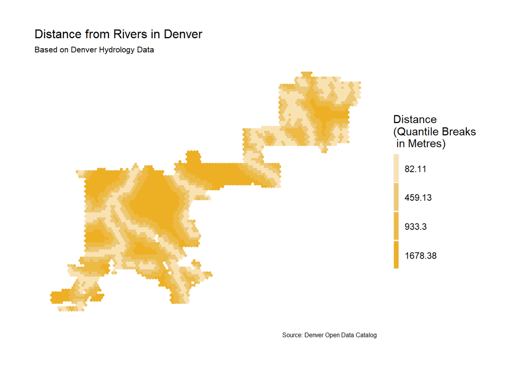

```r
ggplot() +
  geom_sf(data=denver_dat, aes(fill=factor(ntile(streamdist_min,4))),
            colour=NA) +
  scale_fill_manual(values = yellows,
                    labels= as.character(round(quantile(denver_dat$streamdist_min,                                                    c(0.2,.4,.6,.8),
                                        na.rm=T), 2)),
     name = "Distance\n(Quantile Breaks\n in Metres)") +
  labs(title="Distance from Rivers in Denver",
       subtitle="Based on Denver Hydrology Data",
        caption = "Source: Denver Open Data Catalog") +
  mapTheme
```

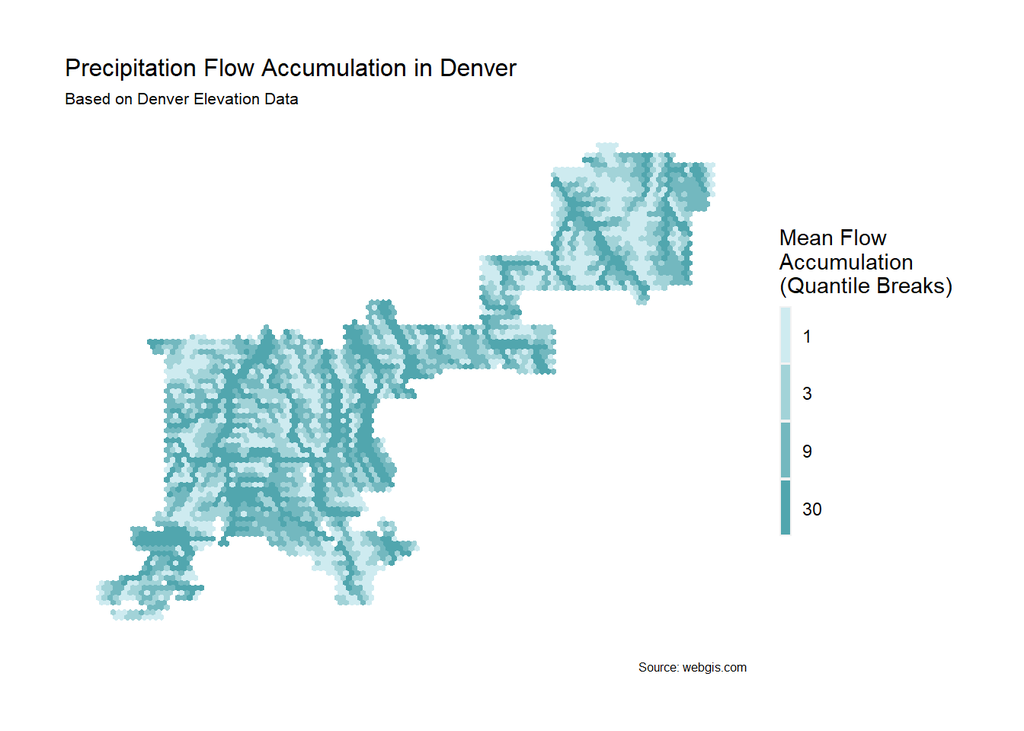

```r
ggplot() +
  geom_sf(data=denver_dat, aes(fill=factor(ntile(flowac_mean,4))),
            colour=NA) +
  scale_fill_manual(values = blues,
                    labels= as.character(round(quantile(denver_dat$flowac_mean,
                                                 c(0.2,.4,.6,.8),
                                                 na.rm=T))),
                    name = "Mean Flow\nAccumulation\n(Quantile Breaks)") +
  labs(title="Precipitation Flow Accumulation in Denver",
       subtitle="Based on Denver Elevation Data",
        caption = "Source: webgis.com") +
  mapTheme
```

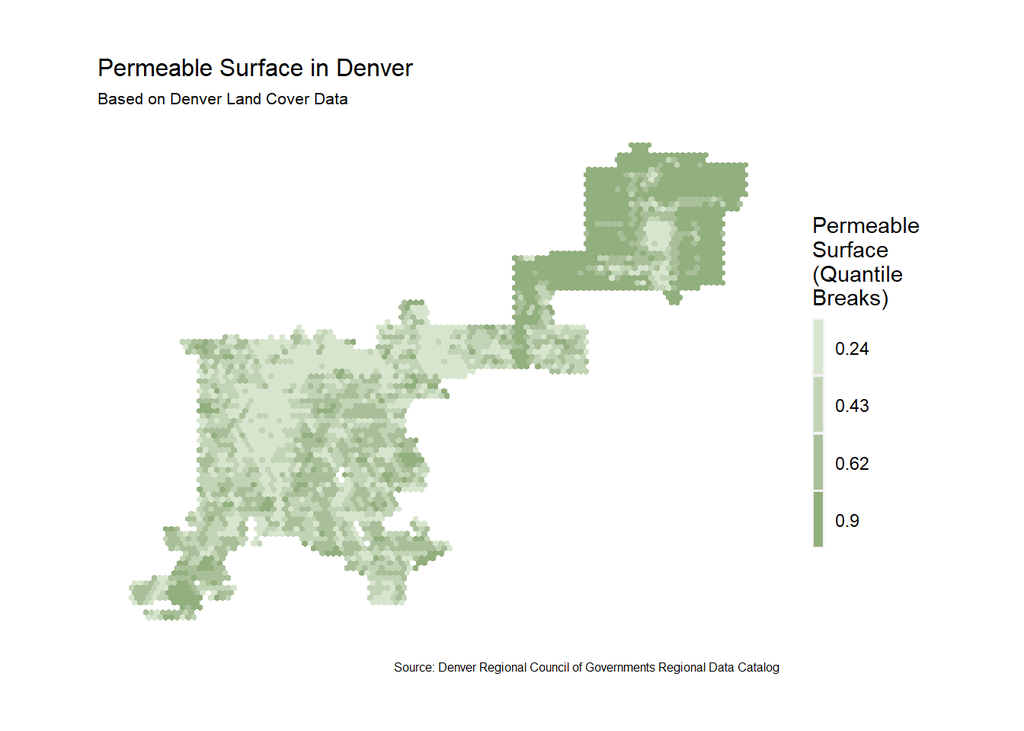

```r
ggplot() +
  geom_sf(data=denver_dat, aes(fill=factor(ntile(pervious_mean,4))),
            colour=NA) +
  scale_fill_manual(values = greens,
                    labels= as.character(round(quantile(denver_dat$pervious_mean,
                                                 c(0.2,.4,.6,.8),
                                                 na.rm=T), 2)),
                    name = "Permeable\nSurface\n(Quantile\nBreaks)") +
  labs(title="Permeable Surface in Denver",
       subtitle="Based on Denver Land Cover Data",
        caption = "Source: Denver Regional Council of Governments Regional Data Catalog") +
  mapTheme
```

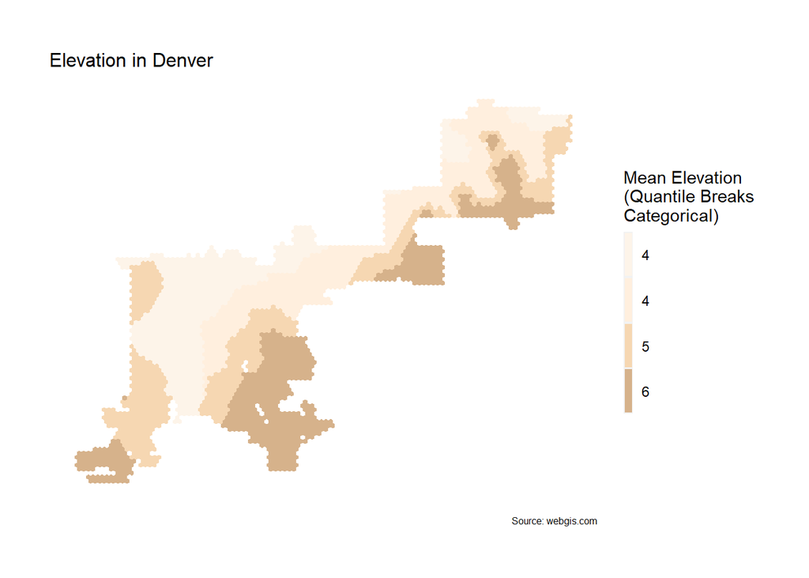

```r
ggplot() +
  geom_sf(data=denver_dat, aes(fill=factor(ntile(elevation_mean,4))),
            colour=NA) +
  scale_fill_manual(values = neutrals,
                    labels= as.character(round(quantile(denver_dat$elevation_mean,
                                                 c(0.2,.4,.6,.8),
                                                 na.rm=T))),
                    name = "Mean Elevation\n(Quantile Breaks\nCategorical)") +
  labs(title="Elevation in Denver",
        caption = "Source: webgis.com") +
  mapTheme
```

## What is our Data Telling Us?

We had to log adjust our Flow Accumulation and Distance to Stream variables to compensate the wide range of outliers in the data set.

```r
calg_PlotVariables <- calg_dat %>%
  as.data.frame() %>%
    dplyr::select(inund_sum, pervious_mean, elevation_mean, flowac_mean_log, streamdist_min_log) %>%
    pivot_longer(cols = -inund_sum)
```

The violin plots below shows how each variable is spread across 0/1 values of inundation.

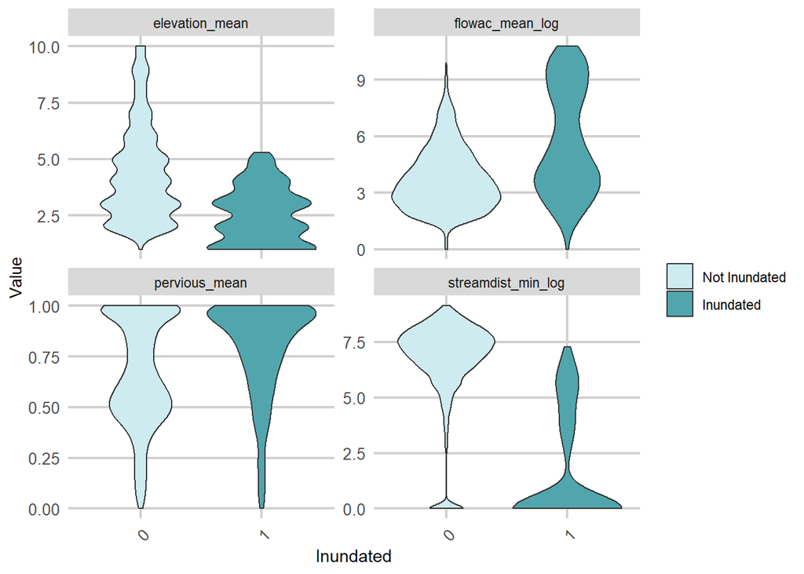

```r
#violin plots
#change code for for calgary_dat
##use boxplots with scatter points to visualize the spread of data?

ggplot(calg_PlotVariables) +
     geom_violin(aes(x = as.factor(inund_sum),
                  y = value, fill = as.factor(inund_sum))) +
     facet_wrap(~name, scales = "free_y") +
     labs(x="Inundated", y="Value") +
     scale_fill_manual(values = c("#CEEBF0", "#51A6AE"),
     labels = c("Not Inundated","Inundated"), name = "") +
     labs(x="Inundated", y="Value") +
  plotTheme
```

```r
##facet_wrap - one ggplot recipe for each variable
###use scales = free or free_y to plot values that are comparatively lower or higher
```

Before running regression models, we checked the correlation values of our variables and found they did not contain high levels of multi-collinearity.

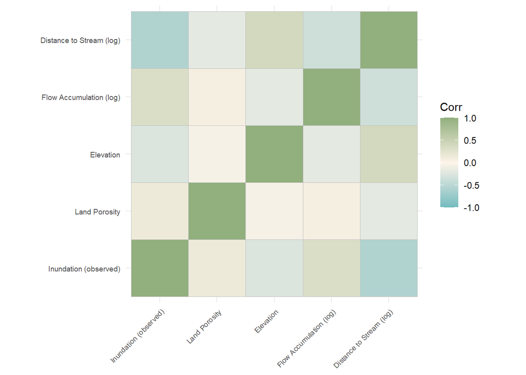

```r
corr <- calg_dat %>%
  as.data.frame() %>%
  dplyr::select(inund_sum, pervious_mean, elevation_mean, flowac_mean_log, streamdist_min_log) %>%
  rename("Distance to Stream (log)" = streamdist_min_log,
         "Flow Accumulation (log)" = flowac_mean_log,
         "Elevation" = elevation_mean,
         "Land Porosity" = pervious_mean,
         "Inundation (observed)" = inund_sum)


calg_matrix = cor(corr)

ggcorrplot(calg_matrix, method="square", colors = c("#73BBBF", "#FDF4E9", "#92AF7E"),
           tl.cex=7)
```

```r
calg_inund_fishnet <- calg_dat %>%
  filter(inund_sum == 1)

no_fishnets <-(509/5373)*100
```

# Logistic Regressions

```r
set.seed(3456)

trainIndex <- createDataPartition(calg_dat$elevation_mean, p = .70,
                                  list = FALSE,
                                  times = 1)

inundTrain <- calg_dat[ trainIndex,] %>%
  dplyr::select(-flowac_mean, -streamdist_min)

inundTest  <- calg_dat[-trainIndex,]%>%
  dplyr::select(-flowac_mean, -streamdist_min)

##the sets are randomly generated
##p=0.70 indicates the 70/30 partition
```

We created 3 logistic regression models.

The first model incorporated all our original variables.

All the variables made the model better, except for land porosity.

We found that:

** A unit increase in Land Porosity *reduces* the chances of inundation by 30%

** A unit increase in Elevation *reduces* the chances of flood inundation by 47%

** A unit increase in Distance to Streams *reduces* the odds of flood inundation by 41%

```r
inundModel <- glm(inund_sum ~ .,
                    family="binomial"(link="logit"), data = inundTrain %>%
                                                            as.data.frame() %>%
                                                            dplyr::select(-geometry, -uniqueID))
summary(inundModel)
```

```
##
## Call:
## glm(formula = inund_sum ~ ., family = binomial(link = "logit"),
##     data = inundTrain %>% as.data.frame() %>% dplyr::select(-geometry,
##         -uniqueID))
##
## Deviance Residuals:
##      Min        1Q    Median        3Q       Max
## -1.97219  -0.26735  -0.15085  -0.06525   2.96692
##
## Coefficients:
##                    Estimate Std. Error z value             Pr(>|z|)
## (Intercept)         1.81143    0.40791   4.441           0.00000896 ***
## pervious_mean      -0.36485    0.30667  -1.190              0.23417
## elevation_mean     -0.63572    0.06873  -9.250 < 0.0000000000000002 ***
## flowac_mean_log     0.10099    0.03350   3.014              0.00258 **
## streamdist_min_log -0.52888    0.02738 -19.319 < 0.0000000000000002 ***
## ---
## Signif. codes:  0 '***' 0.001 '**' 0.01 '*' 0.05 '.' 0.1 ' ' 1
##
## (Dispersion parameter for binomial family taken to be 1)
##
##     Null deviance: 2296.9  on 3762  degrees of freedom
## Residual deviance: 1249.8  on 3758  degrees of freedom
## AIC: 1259.8
##
## Number of Fisher Scoring iterations: 7
```

```r
## % change in Y for unit change in X = [(exponent (coefficient of X) - 1)] * 100
## - or + sign indicates associated increase or decrease

inundModel$coefficients

inundModel_vars <- c("Land Porosity", "Elevation", "Flow Accumulation (log)", "Distance to Stream (log)")
inundModel_coeffs <- c(((exp(-0.3648453 ) - 1) * 100), ((exp(-0.6357177) - 1) * 100), ((exp(0.1009900) - 1) * 100), ((exp( -0.5288784) - 1) * 100))

inundModel_coefficients <- data.frame(inundModel_vars, inundModel_coeffs)

inundModel_coefficients %>%
  kbl(caption = "Exponentiated Coefficients: Logistic Regression Model 1") %>%
   kable_styling(bootstrap_options = "striped", full_width = F, position = "left")
```

## Regress: Model 2 & 3

**Model 2: Does ‘Land Porosity’ matter?**

In the second model, we eliminated Land Porosity, which did not initially exhibit statistical significance.

- The result shows that all independent variables are statistically significant.
- The AIC is only marginally lower than our first model, at **1259.2**.

```r
inundTrain_2 <- calg_dat[ trainIndex,] %>%
  dplyr::select(-flowac_mean, -streamdist_min, -pervious_mean)

inundTest_2  <- calg_dat[-trainIndex,]%>%
  dplyr::select(-flowac_mean, -streamdist_min, -pervious_mean)


inundModel_2 <- glm(inund_sum ~ .,
                    family="binomial"(link="logit"), data = inundTrain_2 %>%
                                                            as.data.frame() %>%
                                                            dplyr::select(-geometry, -uniqueID))
summary(inundModel_2)
```

[output not shown]

```r
## % change in Y for unit change in X = [(exponent (coefficient of X) - 1)] * 100
## - or + sign indicates associated increase or decrease

inundModel_2$coefficients

inundModel2_vars <- c("Elevation", "Flow Accumulation (log)", "Distance to Stream (log)")
inundModel2_coeffs <- c(((exp(-0.6243868) - 1) * 100), ((exp(0.1009589) - 1) * 100), ((exp(-0.5192783) - 1) * 100))

inundModel2_coefficients <- data.frame(inundModel2_vars, inundModel2_coeffs)

inundModel2_coefficients %>%
  kbl(caption = "Exponentiated Coefficients: Logistic Regression Model 2") %>%
   kable_styling(bootstrap_options = "striped", full_width = F, position = "left")
```

**Model 3: What if we don’t log-adjust our variables?**

In model 3, we used non-log-adjusted variables for Distance to Stream and Flow Accumulation.

- All variables except Land Porosity are statistically significant.
- The AIC is lower than the previous two models at **1185.2**

But it messes with our coefficient interpretation, exhibiting oddly low relationships funky, given that a variation in distance from a stream should logically affect the odds of inundation a lot more than 0.46%.

```r
inundTrain_3 <- calg_dat[ trainIndex,] %>%
  dplyr::select(-flowac_mean_log, -streamdist_min_log)

inundTest_3  <- calg_dat[-trainIndex,]%>%
  dplyr::select(-flowac_mean_log, -streamdist_min_log)


inundModel_3 <- glm(inund_sum ~ .,
                    family="binomial"(link="logit"), data = inundTrain_3 %>%
                                                            as.data.frame() %>%
                                                            dplyr::select(-geometry, -uniqueID))
summary(inundModel_3)
```

[output not shown]

```r
## % change in Y for unit change in X = [(exponent (coefficient of X) - 1)] * 100
## - or + sign indicates associated increase or decrease

inundModel_3$coefficients

inundModel3_vars <- c("Land Porosity", "Elevation", "Flow Accumulation", "Distance to Stream")
inundModel3_coeffs <- c(((exp(0.0479009901) - 1) * 100), ((exp(-0.4802761173) - 1) * 100), ((exp(0.0001509916) - 1) * 100), ((exp(-0.0046012831) - 1) * 100))

inundModel3_coefficients <- data.frame(inundModel3_vars, inundModel3_coeffs)

inundModel3_coefficients %>%
  kbl(caption = "Exponentiated Coefficients: Logistic Regression Model 2") %>%
   kable_styling(bootstrap_options = "striped", full_width = F, position = "left")
```

## Model Validation

**So, Is My House Going to Flood?**

We also ran a bunch of tests to validate our model.

The plots below illustrate a distribution of predicted probabilities for the training and test sets, that together, indicate a low overall probability for inundation in Calgary.

But, is that accurate?

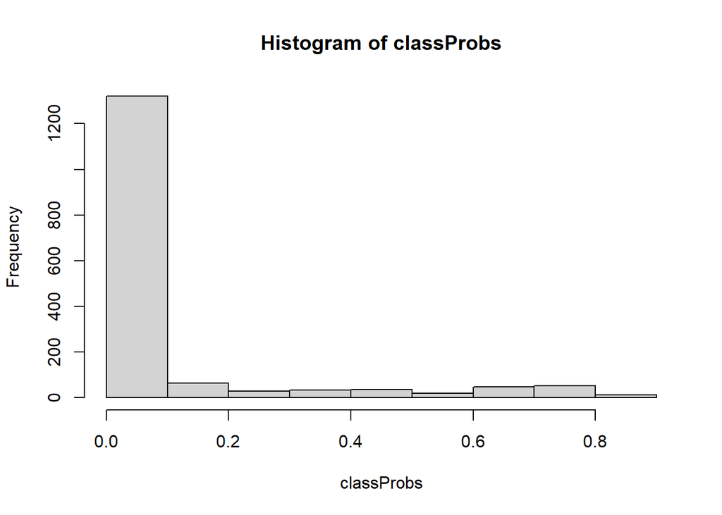

```r
classProbs <- predict(inundModel, inundTest, type="response")


hist(classProbs)
```

```r
##histogram is for the whole dataset
##represents the probability that a cell will be inundated (x-axis), vs number of cells with that probability (y-axis)
```

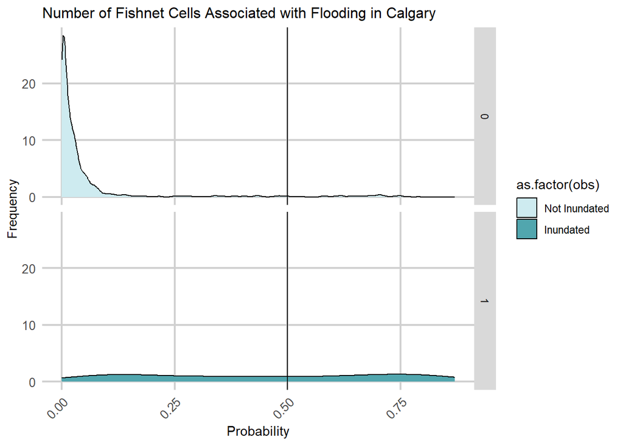

```r
testProbs <- data.frame(obs = as.numeric(inundTest$inund_sum),
                        pred = classProbs)

ggplot(testProbs, aes(x = pred, fill=as.factor(obs))) +
  geom_density() +
  facet_grid(obs ~ .) +
  xlab("Probability") +
  ylab("Frequency") +
  geom_vline(xintercept = .5) +
  scale_fill_manual(values = c("#CEEBF0", "#51A6AE"),
                      labels = c("Not Inundated","Inundated")) +
  labs(title = "Number of Fishnet Cells Associated with Flooding in Calgary")+
  plotTheme
```

# Confusion Metrics

To test the model’s prediction accuracy, we created a confusion matrix to gauge its margin of error.

- Assuming a probability cutoff threshold of **50%**, our matrix gives us an accuracy of **91%**.

```r
testProbs$predClass  = ifelse(testProbs$pred > .5 ,1,0)

caret::confusionMatrix(reference = as.factor(testProbs$obs),
                       data = as.factor(testProbs$predClass),
                       positive = "1")
```

```
## Confusion Matrix and Statistics
##
##           Reference
## Prediction    0    1
##          0 1389   91
##          1   55   75
##
##                Accuracy : 0.9093
##                  95% CI : (0.8942, 0.9229)
##     No Information Rate : 0.8969
##     P-Value [Acc > NIR] : 0.053027
##
##                   Kappa : 0.4576
##
##  Mcnemar's Test P-Value : 0.003772
##
##             Sensitivity : 0.45181
##             Specificity : 0.96191
##          Pos Pred Value : 0.57692
##          Neg Pred Value : 0.93851
##              Prevalence : 0.10311
##          Detection Rate : 0.04658
##    Detection Prevalence : 0.08075
##       Balanced Accuracy : 0.70686
##
##        'Positive' Class : 1
##
```

```r
testProbs$predClass75  = ifelse(testProbs$pred > .75 ,1,0)

caret::confusionMatrix(reference = as.factor(testProbs$obs),
                       data = as.factor(testProbs$predClass75),
                       positive = "1")


testProbs$predClass25  = ifelse(testProbs$pred > .25 ,1,0)

caret::confusionMatrix(reference = as.factor(testProbs$obs),
                       data = as.factor(testProbs$predClass25),
                       positive = "1")
```

## ROC Curve

But how well would it predict on other datasets?

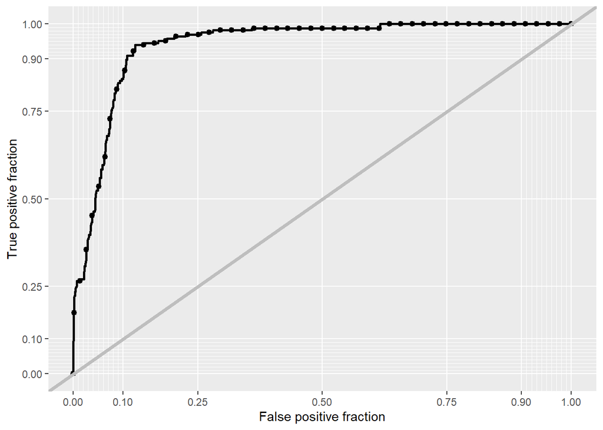

```r
ggplot(testProbs, aes(d = obs, m = pred)) +
  geom_roc(n.cuts = 50, labels = FALSE) +
  style_roc(theme = theme_grey) +
  geom_abline(slope = 1, intercept = 0, size = 1.5, color = 'grey')
```

```r
auc(testProbs$obs, testProbs$pred)
```

```
## Area under the curve: 0.9398
```

## Cross Validation

We checked the prediction performance of our model across 100 randomly generated test sets.

On average, the prediction accuracy across all these test sets is 92%.

A histogram of this shows a high level of **generalizability**, that is, a measure of the model’s capacity to be applied to predict other sample sets – which in our case, made us more confident it would work for Denver.

```r
ctrl <- trainControl(method = "cv",
                     number = 100,
                     savePredictions = TRUE)

inundFit <- train(as.factor(inund_sum) ~ .,
               data = calg_dat %>%
                 as.data.frame() %>%
                 dplyr::select(inund_sum, pervious_mean, elevation_mean, flowac_mean_log, streamdist_min_log),
               method="glm", family="binomial",
               trControl = ctrl)

inundFit

#inundFit is our model trained to predict using the binomial logistic regression, or glm, method.
```

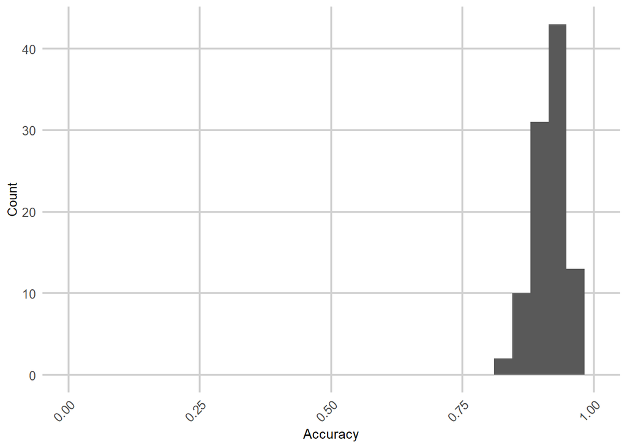

```r
ggplot(as.data.frame(inundFit$resample), aes(Accuracy)) +
  geom_histogram() +
  scale_x_continuous(limits = c(0, 1)) +
  labs(x="Accuracy",
       y="Count")+
  plotTheme
```

# Mapping Predictions

Mapping our predicted inundation values in Calgary against observed inundation values showed us a good fit!

```r
calg_dat_log <- calg_dat %>%
  dplyr::select(uniqueID, inund_sum, pervious_mean, elevation_mean, flowac_mean_log, streamdist_min_log, geometry)


allPredictions <-
  predict(inundFit, calg_dat, type="prob")[,2]

calg_pred <-
  cbind(calg_dat_log,allPredictions) %>%
  mutate(allPredictions = round(allPredictions * 100))
```

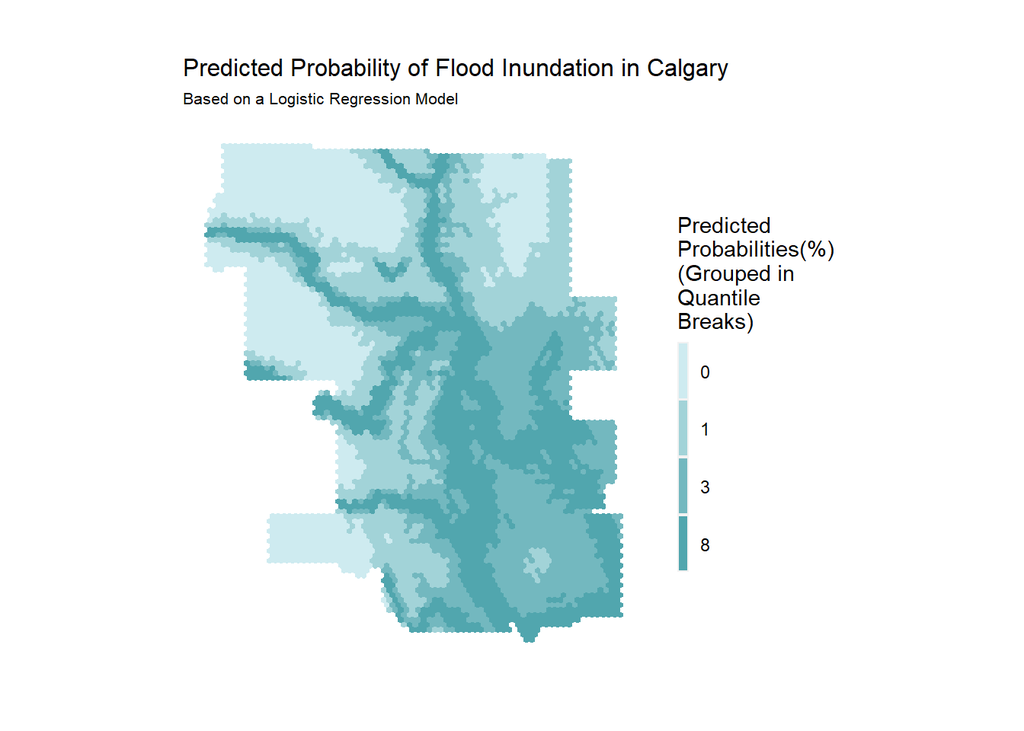

```r
 ggplot() +
    geom_sf(data=calg_pred, aes(fill=factor(ntile(allPredictions,4))),
            colour=NA) +
    scale_fill_manual(values = blues,
                      labels=as.character(quantile(calg_pred$allPredictions,
                                                 c(0.2,.4,.6,.8),
                                                 na.rm=T)),
                      name="Predicted\nProbabilities(%)\n(Grouped in\nQuantile\nBreaks)") +
  mapTheme +
  labs(title="Predicted Probability of Flood Inundation in Calgary",
       subtitle = "Based on a Logistic Regression Model")
```

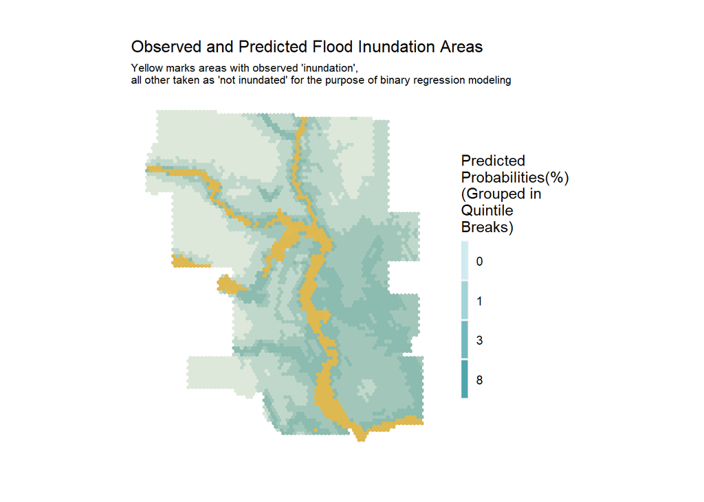

```r
 ggplot() +
  geom_sf(data=calg_pred, aes(fill=factor(ntile(allPredictions,4))), colour=NA) +
  scale_fill_manual(values = blues,
                    labels=as.character(quantile(calg_pred$allPredictions,
                                                 c(.2,.4,.6,.8),
                                                 na.rm=T)),
                    name="Predicted\nProbabilities(%)\n(Grouped in\nQuintile\nBreaks)") +
  geom_sf(data=calg_pred  %>%
               filter(inund_sum == 1),
               fill="#EDBA46", alpha=0.9, colour=NA) +
    geom_sf(data=calg_pred %>%
              filter(inund_sum == 0),
            fill="#F9E2B2", alpha=0.35,colour=NA) +
  mapTheme +
  labs(title="Observed and Predicted Flood Inundation Areas",
       subtitle="Yellow marks areas with observed 'inundation', \nall other taken as 'not inundated' for the purpose of binary regression modeling")
```

**Errors on Map**

An error map spatially laid out our false negatives and positives. IT leads us to think we may have over-predicted flooding in low elevation areas, and, by initially classifiying land porosity as a binary of land cover, we may have reduced the nuances in soil run-off and flooding.

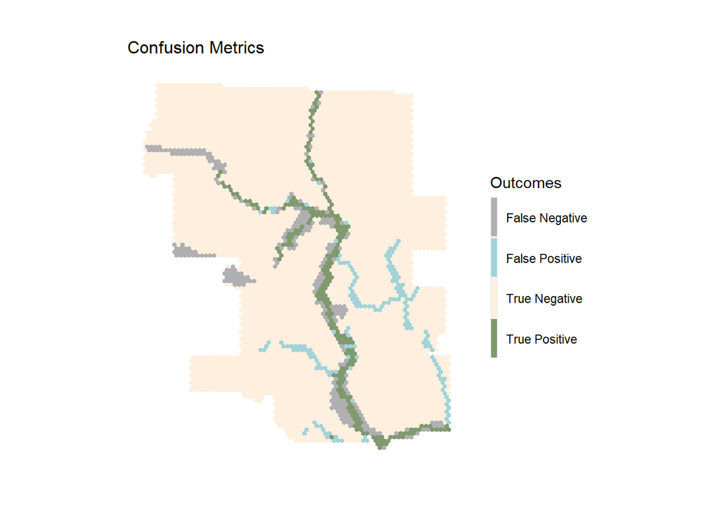

```r
calg_pred %>%
  mutate(confResult=case_when(allPredictions < 50 & inund_sum==0 ~ "True Negative",
                              allPredictions >= 50 & inund_sum==1 ~ "True Positive",
                              allPredictions < 50 & inund_sum==1 ~ "False Negative",
                              allPredictions >= 50 & inund_sum==0 ~ "False Positive")) %>%
  ggplot()+
  geom_sf(aes(fill = confResult), color = "transparent")+
  scale_fill_manual(values = c("#B0B0B3","#A2D3D8","#FFEFDE","#81996F"),
                    name="Outcomes")+
  labs(title="Confusion Metrics") +
  mapTheme
```